# R Notebook : For Hyper parameter optimization

# Analysis of QE along with other hyperparameter

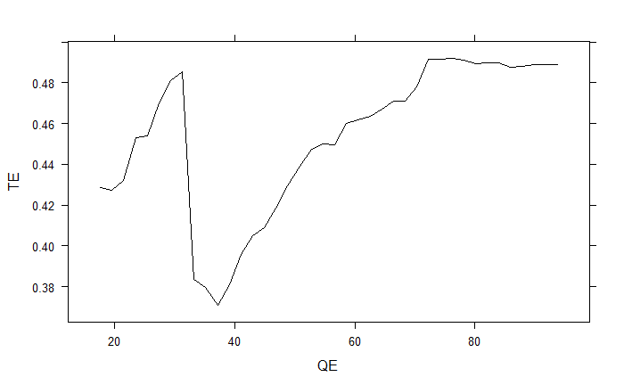

```r
p_TE_12 <-partial(rf_model_target_TE, pred.var = c("QE") , grid.resolution = 40 )
p_TE_13 <-partial(rf_model_target_TE, pred.var = c("QE","dimension") , grid.resolution = 40)
p_TE_14 <-partial(rf_model_target_TE, pred.var = c("QE","init_proto") , grid.resolution = 40)
p_TE_15 <-partial(rf_model_target_TE, pred.var = c("QE","eps_0") , grid.resolution = 40)
p_TE_16 <-partial(rf_model_target_TE, pred.var = c("QE","scaling") , grid.resolution = 40)

pdp_TE_12<- plotPartial(p_TE_12,ylab="TE")
pdp_TE_13<- plotPartial(p_TE_13,ylab="TE")
pdp_TE_14<- plotPartial(p_TE_14,ylab="TE")
pdp_TE_15<- plotPartial(p_TE_15,ylab="TE")
pdp_TE_16<- plotPartial(p_TE_16,ylab="TE")

pdp_TE_12
```

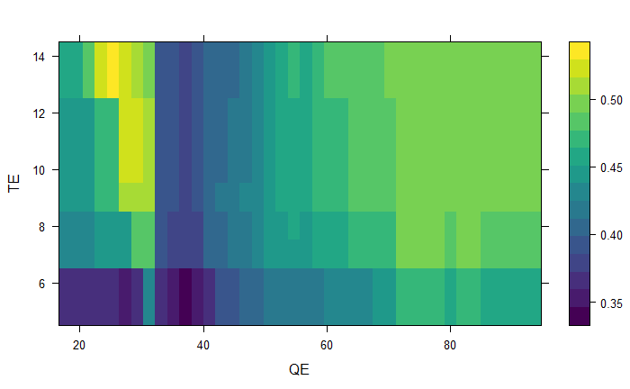

```r
pdp_TE_13
```

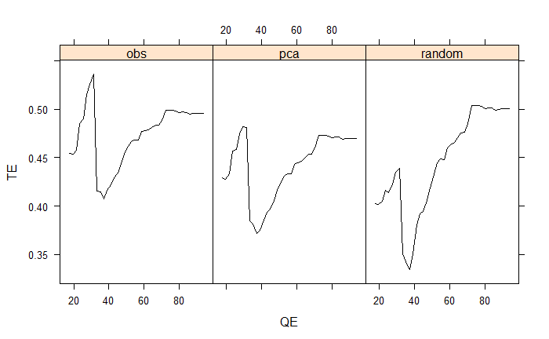

```r
pdp_TE_14
```

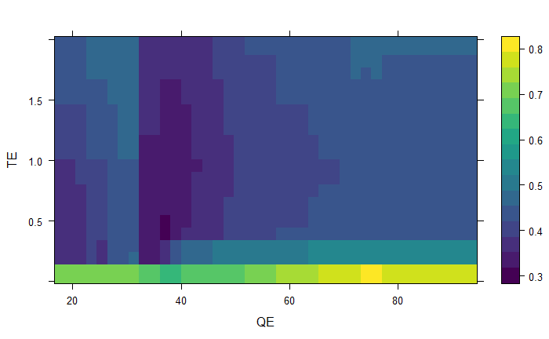

```r
pdp_TE_15
```

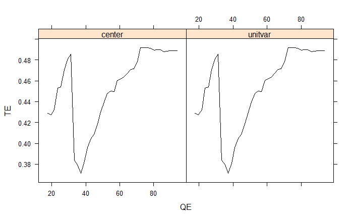

```r
pdp_TE_16
```

- Plot 1 QE and TE lowest values QE aprox 38 -> TE was the lowest QE was the arnd 35 -> TE was second lowest
- Plot 2 for dimension 5 & 6 .. QE and TE were lowest

*Plot 4 for low eps_0…. QE varies from 20 to 100 and TE is always more than 0.6

Radius: guassian distance: maximum, euclidean and minkowaski initi proto: random dimension: 5,6 eps_0 : greater than 0.25 scaling : both have similar graph

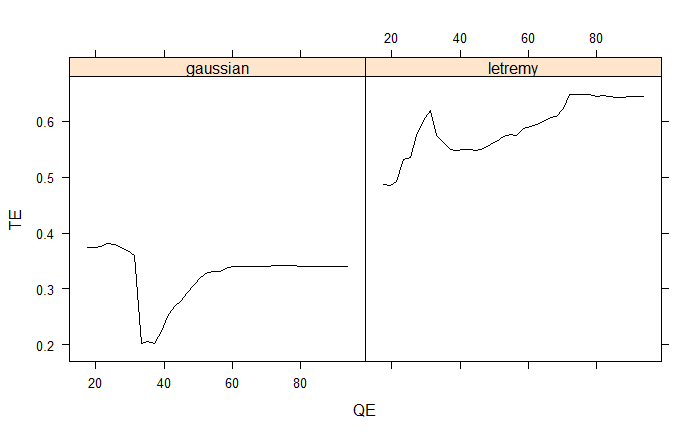

```r
p_TE_QE_1 <- partial(rf_model_target_TE, pred.var = c("QE","neigh_function") , grid.resolution = 40 )
p_TE_QE_2 <- partial(rf_model_target_TE, pred.var = c("QE","distance_func") , grid.resolution = 40 )


pdp_TE_QE_1<- plotPartial(p_TE_QE_1,ylab="TE")
pdp_TE_QE_2<- plotPartial(p_TE_QE_2,ylab="TE")
#pdp_TE_3<- plotPartial(p_TE_3,ylab="TE")
#pdp_TE_4<- plotPartial(p_TE_4,ylab="TE")

pdp_TE_QE_1
```

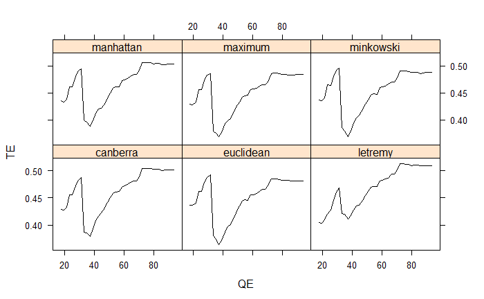

```r
pdp_TE_QE_2
```

```r
#pdp_TE_3
#pdp_TE_4
```

#QE as target and hyper parameter along with TE

```r
head(model_df_FS1_T0_TE_QE)
```

|  | dimension | neigh_function | distance_func | init_proto | eps_0 | TE | QE | scaling | Max_Itr |
| --- | --- | --- | --- | --- | --- | --- | --- | --- | --- |
| 1 | 5 | gaussian | euclidean | random | 0.01 | 0.8961561 | 67.52452 | unitvar | 50 |
| 2 | 7 | gaussian | euclidean | random | 0.01 | 0.9127940 | 75.32251 | unitvar | 50 |
| 3 | 9 | gaussian | euclidean | random | 0.01 | 0.9541021 | 69.78615 | unitvar | 50 |
| 4 | 10 | gaussian | euclidean | random | 0.01 | 0.9248422 | 75.38731 | unitvar | 50 |
| 5 | 14 | gaussian | euclidean | random | 0.01 | 0.9954102 | 67.62518 | unitvar | 50 |
| 6 | 5 | letremy | letremy | random | 0.01 | 0.8542742 | 81.58464 | unitvar | 50 |

```r
rf_model_target_QE <- randomForest(QE ~ ., data = model_df_FS1_T0_TE_QE,importance=TRUE ,proximity=TRUE, oob.prox=TRUE)
```

```r
rf_model_target_QE
```

```
Call:
 randomForest(formula = QE ~ ., data = model_df_FS1_T0_TE_QE,      importance = TRUE, proximity = TRUE, oob.prox = TRUE)
               Type of random forest: regression
                     Number of trees: 500
No. of variables tried at each split: 2

          Mean of squared residuals: 12.79414
                    % Var explained: 77.87
```